# causalDisco

```r
library(causalDisco)
```

This vignette provides an overview of the causalDisco package, which offers tools for causal discovery from observational data. It covers the main features of the package, including various causal discovery algorithms, knowledge incorporation, and result visualization.

# Running causal discovery algorithms

We will for this section use the `num_data` dataset included in the package for demonstrating how to run causal discovery algorithms. It contains 5 numerical variables, `X1, X2, X3, Z`, and `Y`.

```r
data(num_data)
head(num_data)
```

```
#>         X1        X2       X3         Z        Y
#> 1 3.900715  7.048325 6.964806 10.272479 15.35505
#> 2 4.736112  6.236746 5.666022 10.357262 23.36749
#> 3 4.657992 12.169805 9.127046  9.138338 25.32495
#> 4 5.176469  6.392344 6.101088 10.808335 26.75643
#> 5 4.535538 10.305236 7.465185 10.612735 22.67612
#> 6 4.885914 10.018856 7.413312  9.375931 28.03132
```

To make the different causal graphs easier to interpret, we define a custom fixed layout for plotting the results:

```r
plot_layout <- data.frame(
  name = c("Z", "X3", "X1", "X2", "Y"),
  x = c(0.00, 0.50, 0.00, 0.50, 0.25),
  y = c(0.0, 0.0, 0.5, 0.5, 1.0)
)
```

To run a causal discovery algorithm, we first define the algorithm using the corresponding function, and then pass it to the `disco()` function along with the data. Below we demonstrate this process using the Peter-Clark (PC) algorithm from bnlearn with Fisher’s Z test:

```r
pc_bnlearn <- pc(
  engine = "bnlearn", # Use the bnlearn implementation
  test = "fisher_z", # Use Fisher's Z test for conditional independence
  alpha = 0.05 # Significance level for the test
)
pc_result_bnlearn <- disco(data = num_data, method = pc_bnlearn)
```

We can visualize the results using `plot()`:

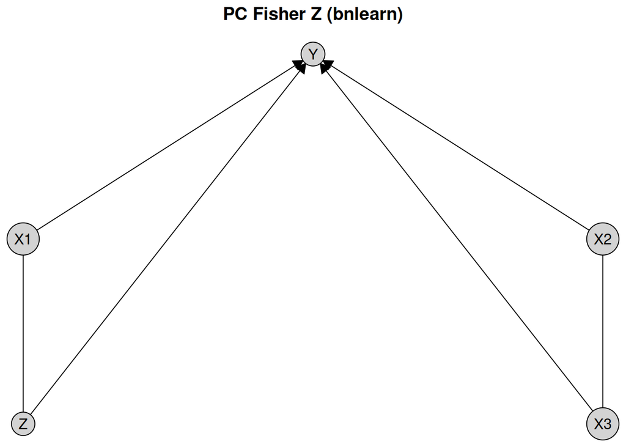

```r
plot(pc_result_bnlearn, layout = plot_layout, main = "PC Fisher Z (bnlearn)")
```

To view all engines available for a specific algorithm, you can see the documentation using `?pc`, where all options are listed under the `engine` argument. Instead of using bnlearn, we can also use the PC implementation from the pcalg package with the same test:

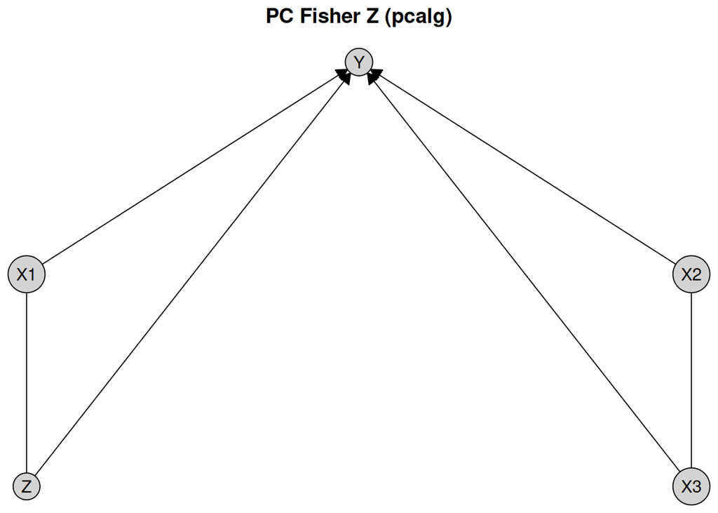

```r
pc_pcalg <- pc(
  engine = "pcalg", # Use the pcalg implementation
  test = "fisher_z", # Use Fisher's Z test for conditional independence
  alpha = 0.05 # Significance level for the test
)
pc_result_pcalg <- disco(data = num_data, method = pc_pcalg)
plot(pc_result_pcalg, layout = plot_layout, main = "PC Fisher Z (pcalg)")
```

We see that the results using the PC algorithm implemented in bnlearn and pcalg gives the same output on this dataset.

You can also use a different algorithm altogether, such as the GES algorithm. It follows the same pattern, however GES is a score-based algorithm, so instead of a test and an alpha level, we need to specify a score. Below we will use the Extended Bayesian Information Criterion (EBIC) score from Tetrad.

**Tetrad Setup Instructions**

causalDisco provides an interface to the Java library [Tetrad](https://github.com/cmu-phil/tetrad) for causal discovery algorithms. To use algorithms from Tetrad you need to install a Java Development Kit (JDK) >= 21. We recommend Eclipse Temurin (OpenJDK), available at https://adoptium.net/en-GB/temurin/releases. When using the installer from the Temurin website, make sure to select the option to set the `JAVA_HOME` environment variable during installation, so rJava correctly detects the Java installation.

For a simpler setup, we recommend using the rJavaEnv package, which provides a convenient function to install Java and configure the environment automatically for rJava. You can install Java using the `rJavaEnv::java_quick_install()` function:

```r
# Use the development version of rJavaEnv from GitHub
# pak::pak("e-kotov/rJavaEnv")
rJavaEnv::java_quick_install(version = 25, distribution = "Temurin")
```

Once you have Java JDK set up correctly, the current supported version of Tetrad can then be installed by calling

```r
install_tetrad()
```

To verify everything is set up correctly you can run `verify_tetrad()`:

```r
verify_tetrad()
```

```
#> $installed
#> [1] TRUE
#>
#> $version
#> [1] "7.6.10"
#>
#> $java_ok
#> [1] TRUE
#>
#> $java_version
#> [1] "25.0.2"
#>
#> $message
#> [1] "Tetrad version 7.6.10 is installed and ready to use."
```

Now you should be able to use Tetrad as an engine for the GES algorithm as shown in the code chunk below.

```r
if (verify_tetrad()$installed && verify_tetrad()$java_ok) {
  ges_tetrad <- ges(
    engine = "tetrad", # Use the Tetrad implementation
    score = "ebic" # Use the EBIC score
  )
  ges_result_tetrad <- disco(data = num_data, method = ges_tetrad)
  plot(ges_result_tetrad, layout = plot_layout, main = "GES EBIC (Tetrad)")
}
```

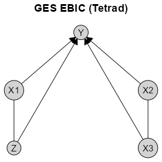

If you want to customize the plot appearance further, you can pass additional arguments to `plot()`. For example, to change the appearance of the nodes, you can use the `node_style` argument:

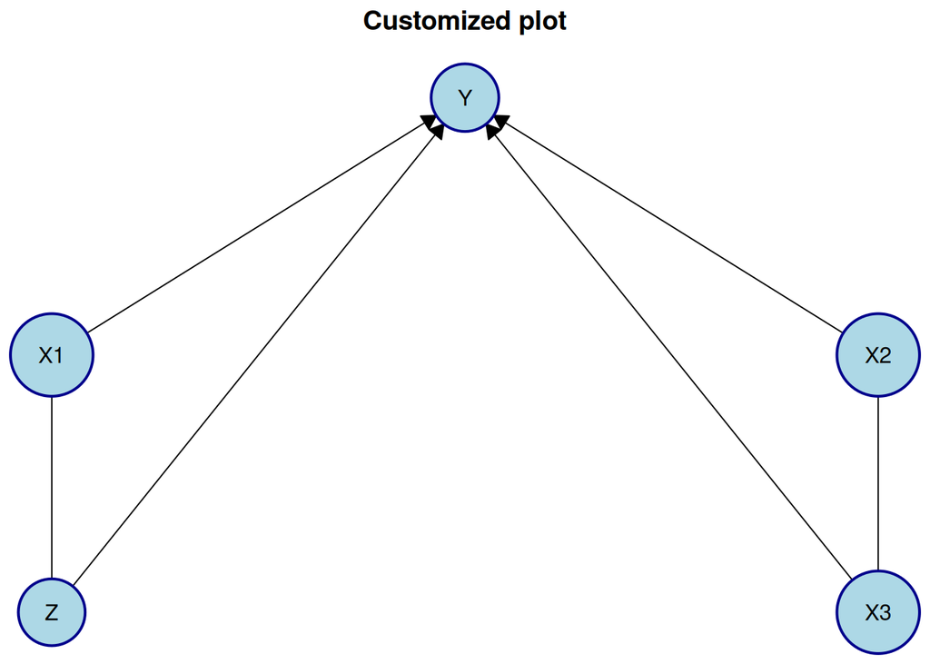

```r
plot(
  pc_result_bnlearn,
  layout = plot_layout,
  main = "Customized plot",
  node_style = list(
    fill = "lightblue", # Fill color
    col = "darkblue", # Border color
    lwd = 2, # Border width
    padding = 4, # Text padding (mm)
    size = 1.2 # Size multiplier
  )
)
```

For more details on customizing plots and generating TikZ code for LaTeX documents, see the visualization vignette.

Instead of using `plot()`, another way to view and analyze the results is to use the `print()` or `summary()` functions:

```r
print(pc_result_bnlearn)
```

```
#>
#> ── caugi graph ─────────────────────────────────────────────────────────────────
#> Graph class: PDAG
#>
#> ── Edges ──
#>
#>   from  edge  to
#>   <chr> <chr> <chr>
#> 1 X1    -->   Y
#> 2 X1    ---   Z
#> 3 X2    ---   X3
#> 4 X2    -->   Y
#> 5 X3    -->   Y
#> 6 Z     -->   Y
#> ── Nodes ──
#>   name
#>   <chr>
#> 1 X1
#> 2 X2
#> 3 X3
#> 4 Z
#> 5 Y
#> ── Knowledge object ────────────────────────────────────────────────────────────
```

```r
summary(pc_result_bnlearn)
```

```
#>
#> ── caugi graph summary ─────────────────────────────────────────────────────────
#> Graph class: PDAG
#> Nodes: 5
#> Edges: 6
#>
#> ── Knowledge summary ──
#>
#> Tiers: 0
#> Variables: 0
#> Required edges: 0
#> Forbidden edges: 0
#>
#> ── Variables per Tier
```

# Incorporating knowledge

We will for this section use the dataset `tpc_example`, which contains variables, which are measured at three different life stages: childhood, youth, and old age.

```r
data(tpc_example)
head(tpc_example)
```

```
#>   child_x2   child_x1    youth_x4 youth_x3  oldage_x6  oldage_x5
#> 1        0 -0.7104066 -0.07355602        1  6.4984994  3.0740123
#> 2        0  0.2568837 -1.16865142        1  0.3254685  1.9726530
#> 3        0 -0.2466919 -0.63474826        1  4.1298927  1.9666697
#> 4        1  1.6524574  0.97115845        0 -7.9064009 -4.5160676
#> 5        0 -0.9516186  0.67069597        0  1.7089134  0.7903853
#> 6        1  1.9549723 -0.65054654        0 -6.9758928 -3.2107342
```

Since we know the temporal ordering of the variables, we can incorporate this background knowledge into the causal discovery algorithm. Specifically, we know that variables measured in childhood cannot be caused by variables measured in youth or old age, and variables measured in youth cannot be caused by variables measured in old age.

Knowledge is encoded by creating a `Knowledge` object via the `knowledge()` function. The first argument (optional, but recommended for name matching) specifies the dataset. Tiered knowledge can then be defined using the `tier()` function. Here, we illustrate this by creating a tiered knowledge structure based on life stages:

```r
kn <- knowledge(
  tpc_example,
  tier(
    child ~ c("child_x1", "child_x2"),
    youth ~ starts_with("youth"), # tidyselect helper; equivalent to c("youth_x3", "youth_x4")
    oldage ~ starts_with("oldage")
  )
)
```

For more details on how to define knowledge, see the knowledge vignette.

You can view the `Knowledge` object using `print()`, `summary()` or `plot()`:

```r
print(kn)
```

```
#>
#> ── Knowledge object ────────────────────────────────────────────────────────────
#>
#> ── Tiers ──
#>
#>   tier
#>   <chr>
#> 1 child
#> 2 youth
#> 3 oldage
#> ── Variables ──
#>   var       tier
#>   <chr>     <chr>
#> 1 child_x1  child
#> 2 child_x2  child
#> 3 youth_x3  youth
#> 4 youth_x4  youth
#> 5 oldage_x5 oldage
#> 6 oldage_x6 oldage
```

```r
summary(kn)
```

```
#> ── Knowledge summary ──
#> Tiers: 3
#> Variables: 6
#> Required edges: 0
#> Forbidden edges: 0
#>
#> ── Variables per Tier
#> child: 2 variables
#> oldage: 2 variables
#> youth: 2 variables
```

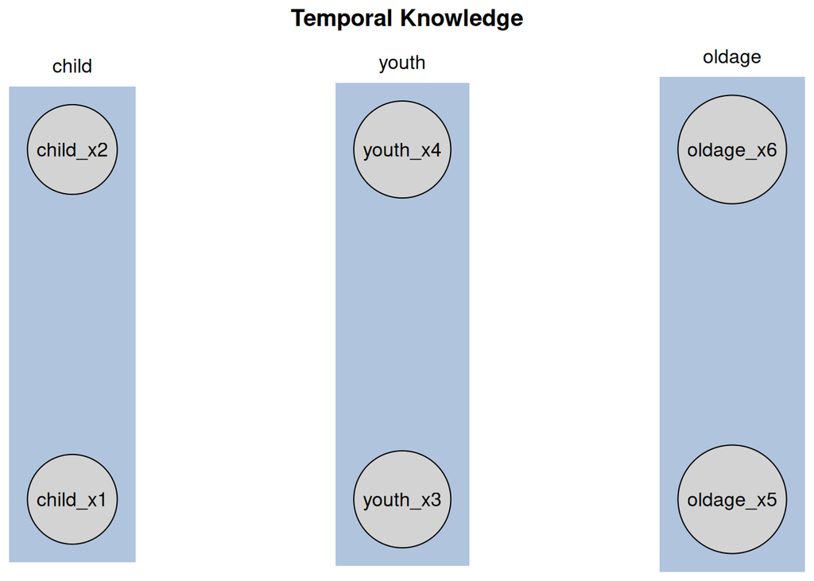

```r
plot(kn, main = "Temporal Knowledge")
```

The plot displays vertical tiers, each enclosed in a shaded rectangle and labeled with the corresponding tier name at the top.

We can then incorporate this knowledge into any algorithm like above. To do so, you need to pass the `Knowledge` object as an argument to the `disco()` function. Here we use the Temporal Peter-Clark (tpc) algorithm from causalDisco with the regression-based information loss test:

```r
tpc_method <- tpc(
  engine = "causalDisco", # Use the causalDisco implementation
  test = "reg" # Use the regression-based information loss test
)
tpc_result <- disco(data = tpc_example, method = tpc_method, knowledge = kn)
```

Similarly, we can view the results using `print()`, `summary()` or `plot()`:

```r
print(tpc_result)
```

```
#>
#> ── caugi graph ─────────────────────────────────────────────────────────────────
#> Graph class: PDAG
#>
#> ── Edges ──
#>
#>   from      edge  to
#>   <chr>     <chr> <chr>
#> 1 child_x1  ---   child_x2
#> 2 child_x2  -->   oldage_x5
#> 3 child_x2  -->   youth_x4
#> 4 oldage_x5 -->   oldage_x6
#> 5 youth_x3  -->   oldage_x5
#> 6 youth_x4  -->   oldage_x6
#> ── Nodes ──
#>   name
#>   <chr>
#> 1 child_x2
#> 2 child_x1
#> 3 youth_x4
#> 4 youth_x3
#> 5 oldage_x6
#> 6 oldage_x5
#> ── Knowledge object ────────────────────────────────────────────────────────────
#> ── Tiers ──
#>
#>   tier
#>   <chr>
#> 1 child
#> 2 youth
#> 3 oldage
#> ── Variables ──
#>   var       tier
#>   <chr>     <chr>
#> 1 child_x1  child
#> 2 child_x2  child
#> 3 youth_x3  youth
#> 4 youth_x4  youth
#> 5 oldage_x5 oldage
#> 6 oldage_x6 oldage
```

```r
summary(tpc_result)
```

```
#> ── caugi graph summary ─────────────────────────────────────────────────────────
#> Graph class: PDAG
#> Nodes: 6
#> Edges: 6
#>
#> ── Knowledge summary ──
#>
#> Tiers: 3
#> Variables: 6
#> Required edges: 0
#> Forbidden edges: 0
#>
#> ── Variables per Tier
#> child: 2 variables
#> oldage: 2 variables
#> youth: 2 variables
```

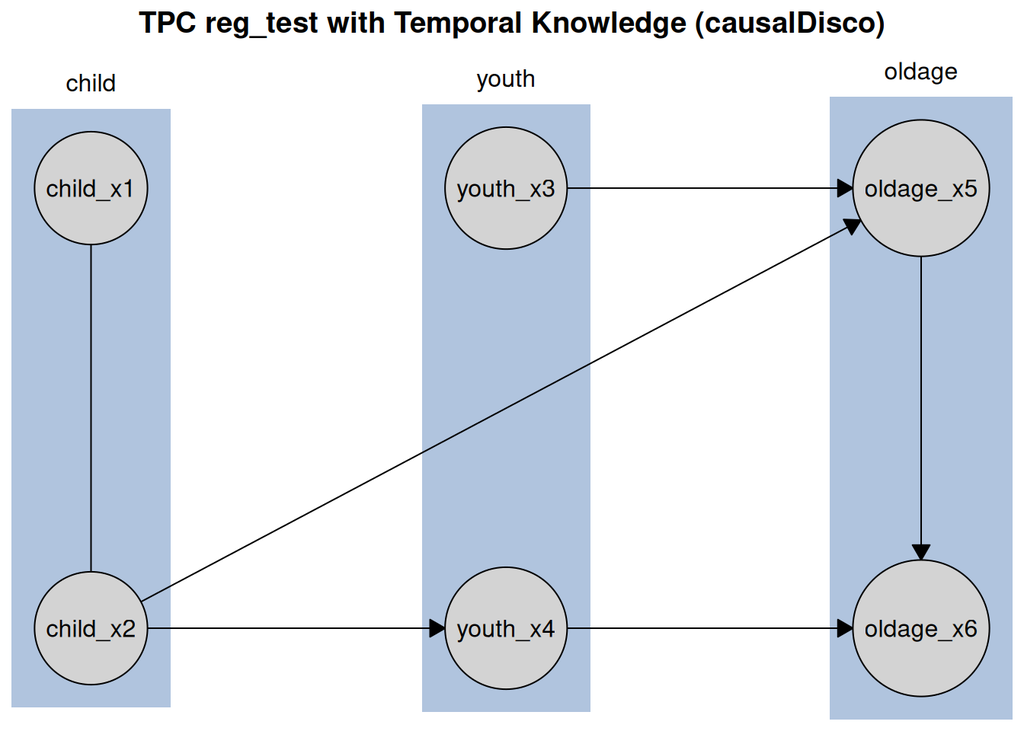

```r
plot(tpc_result, main = "TPC reg_test with Temporal Knowledge (causalDisco)")
```

Like before, the tiered knowledge is reflected in the plot layout, with variables grouped by life stage. Additionally, you can customize the plot appearance further by passing additional arguments to `plot()`.

# Next steps

For more information about how to incorporate knowledge, see the knowledge vignette.

For more information about causal discovery, see the causal discovery vignette.

For more information about visualization options, see the visualization vignette.